# Govhack 2017 data exploration

Ashley Noel Hinton

30 July 2017

```r
library(knitr)
library(rmarkdown)
library(stringi)
```

The day before Govhack started I was standing in a shop looking out onto a busy Karangahape Road intersection, talking to the shop owner about how there were lots of traffic accidents on the intersection. Mostly they were trying to convince an employee to cross at the pedestrian crossing rather than shooting between parked cars. Someone suggested that surely information about how many accidents happened at that intersection must be online somewhere, and they searched on Google to find it. They couldn’t find it.

This hack attempts to at least answer the question: how many traffic accidents happen at this intersection?

## Data source

I will use the [disaggregated crash data](https://www.nzta.govt.nz/safety/safety-resources/road-safety-information-and-tools/disaggregated-crash-data/) from NZ Transport Agency (NZTA) to try to answer this question. The data set has been downloaded and is in this repo as a 62MB CSV file, Disaggregated-crash-data.csv. An accompanying metadata file has also been downloaded from NZTA, disaggregated-crash-data-metadata.csv.

### Load crash data

```r
## this file is *NOT* in UTF-8. best guess at encoding:
rawData = rawToChar(
    readBin("Disaggregated-crash-data.csv", "raw", 100000))
(encoding = stringi::stri_enc_detect(rawData)[[1]]$Encoding[1])
```

```
## [1] "ISO-8859-1"
```

```r
## read the data using this encoding
crashData = read.csv(file = "Disaggregated-crash-data.csv",
                     fileEncoding = encoding)
summary(crashData)
```

```
##    CRASH_YEAR     CRASH_FIN_YEAR   CRASH_SEV   fatal_count
##  Min.   :2000   2007/2008: 12150   F:  5675   Min.   :0.00000
##  1st Qu.:2004   2006/2007: 11787   M:137600   1st Qu.:0.00000
##  Median :2008   2008/2009: 11530   S: 34027   Median :0.00000
##  Mean   :2008   2005/2006: 11134              Mean   :0.03627
##  3rd Qu.:2012   2009/2010: 11011              3rd Qu.:0.00000
##  Max.   :2017   2003/2004: 10704              Max.   :9.00000
##                 (Other)  :108986
##  seriousinj_count  minorinj_count                            MULTI_VEH
##  Min.   : 0.0000   Min.   : 0.00   Multi vehicle                  :82376
##  1st Qu.: 0.0000   1st Qu.: 1.00   Single vehicle                 :64202
##  Median : 0.0000   Median : 1.00   Vehicle(s)+Pedestrian(s)       :16108
##  Mean   : 0.2349   Mean   : 1.08   Vehicle(s)+Cyclist(s) only     :12576
##  3rd Qu.: 0.0000   3rd Qu.: 1.00   Cyclists only                  : 1046
##  Max.   :12.0000   Max.   :34.00   Vehicle(s)+multiple other types:  741
##                                    (Other)                        :  253
##                HOLIDAY                 LG_REGION_DESC      TLA_ID
##  Christmas/New Year:  4887   Auckland         :51818   Min.   : 1.00
##  Easter            :  2079   Canterbury       :22279   1st Qu.: 7.00
##  Labour Weekend    :  1599   Waikato          :20385   Median :25.00
##  None              :167103   Wellington       :15284   Mean   :31.35
##  Queens Birthday   :  1634   Otago            :12809   3rd Qu.:53.00
##                              Manawatu/Wanganui:10372   Max.   :75.00
##                              (Other)          :44355
##               TLA_NAME         AU_ID            MB_ID
##  Auckland         :51813   Min.   :     0   Min.   :      0
##  Christchurch City:14389   1st Qu.:521132   1st Qu.: 663700
##  Dunedin City     : 7154   Median :542550   Median :1304800
##  Wellington City  : 6203   Mean   :550463   Mean   :1464681
##  Hamilton City    : 5096   3rd Qu.:582800   3rd Qu.:2356700
##  Waikato District : 4131   Max.   :627201   Max.   :3194800
##  (Other)          :88516   NA's   :59       NA's   :59
##     EASTING           NORTHING        CRASH_LOCN1
##  Min.   :      0   Min.   :      0   SH 1N  : 12665
##  1st Qu.:1613956   1st Qu.:5403987   SH 1S  :  6179
##  Median :1755778   Median :5714267   SH 2   :  5877
##  Mean   :1702679   Mean   :5598062   SH 3   :  3352
##  3rd Qu.:1793828   3rd Qu.:5911801   SH 6   :  3282
##  Max.   :2110092   Max.   :6189084   SH 16  :  1944
##                                      (Other):144003
```

[output cut: 121 more lines]

```
##  Min.   :0.000000   Min.   :0.00000   Min.   :0.0000000
##  1st Qu.:0.000000   1st Qu.:0.00000   1st Qu.:0.0000000
##  Median :0.000000   Median :0.00000   Median :0.0000000
##  Mean   :0.001229   Mean   :0.00432   Mean   :0.0007953
##  3rd Qu.:0.000000   3rd Qu.:0.00000   3rd Qu.:0.0000000
##  Max.   :1.000000   Max.   :2.00000   Max.   :2.0000000
##
##    Roadworks             Other
##  Min.   :0.0000000   Min.   :0.00000
##  1st Qu.:0.0000000   1st Qu.:0.00000
##  Median :0.0000000   Median :0.00000
##  Mean   :0.0006035   Mean   :0.01092
##  3rd Qu.:0.0000000   3rd Qu.:0.00000
##  Max.   :2.0000000   Max.   :2.00000
##
```

```r
dim(crashData)
```

```
## [1] 177302     73
```

Excellent, 177302 rows in 73 columns of data. What do the variables represent?

### Load crash metadata

```r
## this file is *NOT* in UTF-8. best guess at encoding:
rawMeta = rawToChar(
    readBin("disaggregated-crash-data-metadata.csv", "raw", 100000))
(encoding = stringi::stri_enc_detect(rawMeta)[[1]]$Encoding[1])
```

```
## [1] "windows-1252"
```

```r
## read the data using this encoding
crashMetadata = read.csv(file = "disaggregated-crash-data-metadata.csv",
                         stringsAsFactors = FALSE,
                         fileEncoding = toupper(encoding))
names(crashMetadata)
```

```
## [1] "Variable.Name" "Description"   "X"             "X.1"
## [5] "X.2"
```

```r
## what's in columns 3:5?
head(crashMetadata[, 3:5])
```

```
##    X X.1 X.2
## 1 NA  NA  NA
## 2 NA  NA  NA
## 3 NA  NA  NA
## 4 NA  NA  NA
## 5 NA  NA  NA
## 6 NA  NA  NA
```

```r
## nothing?
all(is.na((crashMetadata)[, 3:5]))
```

```
## [1] TRUE
```

```r
## drop them
crashMetadata = crashMetadata[, 1:2]
```

```r
## print the table
kable(crashMetadata)
```

| Variable.Name | Description |
| --- | --- |
| crash_year | The year in which a crash occurred, if known. |
| crash_fin_year | The financial (fin) year in which a crash occurred, if known. |
| crash_sev | The severity of a crash. Possible values are ‘F’ (fatal), ‘S’ (serious), ‘M’ (minor). This is determined by the worst injury sustained in the crash at time of entry. |
| fatal_count | A count of the number of fatal casualties associated with this crash. |
| seriousinj_count | A count of the number of serious injuries (inj) associated with this crash. |
| minorinj_count | A count of the number of minor injuries (inj) associated with this crash. |
| multi_veh | A variable derived from the number of vehicles which are given roles in the crash. The variable has the following possible values; ‘single vehicle’, ‘multi-vehicle’ , ‘cyclist and vehicle(s)’, ‘pedest… |
| holiday | Indicates where a crash occurred during a ‘Christmas/New Year’, ‘Easter’, ‘Queens Birthday’ or ‘Labour Weekend’ holiday period, otherwise ‘None’. |
| lg_region_desc | Identifies the local government (LG) region. The boundaries match territorial local authority (TLA) boundaries in most places. A blank cell occurs where the crash is said to have occurred in a particu… |
| tla_id | The unique identifier for a territorial local authority (TLA). Each crash is assigned a TLA based on where the crash occurred. |
| tla_name | The name of the territorial local authority (TLA) the crash has been attributed. |
| au_id | The unique identifier of an area unit. |
| mb_id | The unique identifier of a meshblock. |
| easting | The easting coordinate of an object (usually a crash) expressed in NZMG referred to the WGS84 datum to a precision of 1m. |
| northing | The northing coordinate of an object (usually a crash) expressed in NZMG referred to the WGS84 datum to a precision of 1m. |
| crash_locn1 | Part 1 of the ‘crash location’ (crash_locn). May be a road name, route position (RP), landmark, or other, e.g. ‘Ninety Mile Beach’. Used for location descriptions in reports etc. |
| crash_locn2 | Part 2 of the ‘crash location’ (crash_locn). May be a side road name, landmark etc. Used for location descriptions in reports etc. |
| outdtd_locn_desc | Indicates if the location for this crash is an ‘Outdated Location’(outdtd_locn) or ‘Current location’. A crash is said to have an ‘Outdated location’ where the road might have moved, or does not exist… |
| crash_rp_rs | The ‘reference station’ (RS) for the ‘route position’ (RP) of a crash. |
| intersection | Indicate if a crash happened at an ‘Intersection’, ‘At Landmark’ or ‘Unknown’. |
| junction_type | The type of junction the crash happened at. Possible road junctions include ‘Driveway’, ‘Roundabout’, ‘X Type Junction’, ‘T Type Junction’, ‘Y Type Junction’, or ‘Multi Road Join’. The junction type m… |
| cr_rd_side_rd | Indicates whether the principal vehicle in a crash was on the crash road (cr_rd) [1] or side road (sd_rd) [2] at the time of the crash. Note that ‘on side road’ (2) can only happen if the crash occurr… |
| crash_dirn_desc | The direction (dirn) of the crash from the reference point. Values possible are ‘North’, ‘East’, ‘South’ or ‘West’. |
| crash_dist | The distance (dist) of the crash from the reference point for the crash. The reference point is often the intersection of ‘crash road’ and ‘side road’ (refer to ‘cr_rd_sd_rd’ variable). |
| crash_rp_dirn_desc | Indicates the direction of travel (where known) on a State Highway (SH) with respect to the highway origin. Possible values include ‘Increasing’ where the crash occurred in increasing distance from SH… |
| dirn_role1_desc | The direction (dirn) of the principal vehicle involved in the crash. Possible values are North, South, East or West. |
| crash_rp_disp | The displacement (disp) of the crash from a reference station (RS). Part of the crash route position (RP). |
| crash_sh_desc | Indicates where a crash is reported to have occurred on a State Highway (SH). Possible values include ‘Yes’ where the crash occurred on a SH, otherwise ‘No’. |
| crash_rp_sh | The State Highway (SH) on which a crash occurred. This is part of a ‘route position’ (RP) for the crash. Possible values can be any valid natural SH designation reference (e.g. ‘1N’ is SH1 in the Nort… |
| crash_rp_news_desc | Where the crash occurred on a median-divided State Highway (SH), this flag indicates which side of the median the crash happened. Values ‘Northbound’, ‘Southbound, ’Eastbound’ or ‘Westbound’. |
| intsn_midblock | A derived variable to indicate if a crash occured at an intersection (intsn) or not. The ‘intsn_midblock’ variable is calculated using the ‘intersection’ and ‘junction_type’ variables. Values are ‘Int… |
| flat_hill | Whether the road is flat or sloped. Possible values include ‘Flat or ’Hill’. |
| road_character | The general nature of the road. Possible values include ‘Bridge’, ‘Motorway Ramp’, ‘Railway Crossing’ or ‘Unknown’. |
| road_curvature | The curvature of the road. Possible values include ‘Straight Road’, ‘Easy Curve’, ‘Moderate Curve’ or ‘Severe curve’. |
| road_lane | The lane configuration of the road. Possible values : ‘1’ (one way), ‘2’ (two way), ‘M’ (for where a median exists), ‘O’ (for off-road lane configuations), ‘’ ( for unknown or invalid configuarations)… |
| road_markings | The road markings at the crash site. Possible values: ‘Ped Crossing’ (for pedestrian crossings), ‘Raised Island’, ‘Painted Island’, ‘No Passing Lanes’, ‘Centre Line’, ‘No Marks’ or ‘Unknown’. |
| road_surface | The road surface description applying at the crash site. Possible values: ‘Sealed’ or ‘Unsealed’. |
| road_wet | The road wetness at the time and place of the crash. Possible values: ‘Wet’, ‘Dry’, ‘Ice/Snow’ or ‘Unknown’ |
| num_lanes | The number(num) of lanes on the crash road. |
| traffic_ctrl | The traffic control (ctrl) signals at the crash site. Possible values are ‘Traffic Signals’, ‘Stop Sign’, ‘Give Way Sign’, ‘Pointsman’, ‘School Patrol’, ‘Nil’ or ‘N/A’. |
| spd_lim | The speed (spd) limit (lim) in force at the crash site at the time of the crash. May be a number, or ‘LSZ’ for a limited speed zone. |
| adv_spd | The advisory (adv) speed (spd) at the crash site at the time of the crash. |
| tmp_spd_lim | The temporary (temp) speed (spd) limit (lim) at the crash site if one exists (e.g. for road works). |
| urban | A derived variable using the ‘spd_lim’ variable. Possible values are ‘Urban’ (urban, spd_lim < 80) or ‘Open Road’ (open road, spd_lim >=80 or ‘LSZ’). |
| dark_light | A variable derived from the ‘light’ variable. Values ‘Dark’ (if ‘light’ = ‘Dark’ or ‘Twilight’), ‘Light’ ( ‘light’ = ‘Bright’, ‘Overcast’) or ‘Unknown’ (light = ‘’). |
| light | The light at the time and place of the crash. Possible values: ‘Bright Sun’, ‘Overcast’, ‘Twilight, ’Dark’ or ‘Unknown’. |
| street_light | The street lighting at the time of the crash. Possible values ‘On’, ‘Off’, ‘None’ or ‘Unknown’. |
| weather_a | Indicates weather at the crash time/place. See wthr_b. Values that are possible are ‘Fine’, ‘Mist’, ‘Light Rain’, ‘Heavy Rain’, ‘Snow’, ‘Unknown’. |
| weather_b | The weather at the crash time/place. See weather_a. Values ‘Frost’, ‘Strong Wind’ or ‘Unknown’. |
| Post or Pole | Derived variable to indicate how many times a post or pole was struck in the crash. This includes light, power, phone, utility poles and objects practically forming part of a pole (i.e. ‘Transformer G… |
| Guard Rail | Derived variable to indicate how many times a guard or guard rail was struck in the crash. This includes ‘New Jersey’ barriers, ‘ARMCO’, sand filled barriers, wire catch fences, etc. |
| Water/River | Derived variable to indicate how many times a body of water (including rivers, streams, lakes, the sea, tidal flates, canals, watercourses or swanps) was struck in the crash. |
| Cliff Bank | Derived variable to indicate how many times a ‘cliff’ or ‘bank’ was struck in the crash. This includes retaining walls |
| Ditch | Derived variable to indicate how many times a ‘ditch’ or ‘waterable drainage channel’ was struck in a crash. |
| Fence | Derived variable to indicate how many times a ‘fence’ was struck in the crash. This includes letterbox(es), hoardings, private roadside furniture, hedges, sight rails, etc. |
| Kerb | Derived variable to indicate how many times a kerb was struck in the crash, that contributed directly to the crash. |
| Traffic Island | Derived variable to indicate how many times a traffic island, medians (excluding barriers)was struck in the crash. |
| Parked Vehicle | Derived variable to indicate how many times a parked or unattended vehicle was struck in the crash. This variable can include trailers. |
| Traffic Sign | Derived variable to indicate how many times ‘traffic signage’ (including traffic signals, their poles, bollards or roadside delineators) was struck in the crash. |
| Vehicle | Derived variable to indicate how many times a stationary attended vehicle was struck in the crash. This includes broken down vehicles, workmen’s vehicles, taxis, buses. |
| Bridge | Derived variable to indicate how many times a bridge, tunnel, the abutments, handrails were struck in the crash. |
| Over Bank | Derived variable to indicate how many times an embankment was struck or driven over during a crash. This variable includes other vertical drops driven over during a crash. |
| Animals | Derived variable to indicate how many times an ‘Animal(s)’ was struck in the crash. This is used where the animals, being driven or led, were under control. |
| Stray Animal | Derived variable to indicate how many times a stray animal(s) was struck in the crash. This variable includes wild animals such as pigs, goats, deer, straying farm animals, house pets and birds. |
| Obj thrown/dropped | Derived variable to indicate how many times objects were thrown at or dropped on vehicles in the crash. |
| Debris | Derived variable to indicate how many times debris, boulders or items dropped or thrown from a vehicle(s) were struck in the crash |
| House Or Bldg | Derived variable to indicate how many times a houses, garages, sheds or other buildings(Bldg) were struck in the crash |
| Train | Derived variable to indicate how many times a train, rolling stock or jiggers was struck in the crash, whether stationary or moving |
| Phone Box Etc | Derived variable to indicate how many times a telephone kiosk traffic signal controllers, bus shelters or other public furniture was struck in the crash |
| Slip Or Flood | Derived variable to indicate how many times landslips, washouts or floods (excluding rivers) were objects struck in the crash |
| Roadworks | Derived variable to indicate how many times an object associated with ‘roadworks’ (including signs, cones, drums, barriers, but not roadwork vehicles) was struck during the crash |
| Trees | Derived variable to indicate how many times trees or other growing items were struck during the crash. |
| Other | Derived variable to indicate how many times an object was struck in a crash and the object struck was not pre-defined. This variable includes stockpiled materials, rubbish bins, fallen poles, fallen t… |

Keen spotters will notice that the metadata and the column names have inconsistent capitalisation of variables, so I’ll just make all the names of my data rows lower case to prevent confusion (maybe).

```r
names(crashData) = tolower(names(crashData))
```

Useful things I can use:

- `crash_year` between 2000 and 2017
- `fatal_count`, `seriousinj_count`, `minorinj_count` for counts of fatalities, serious injuries, and minor injuries in each crash
- `crash_locn1` and `crash_locn2` should give the street names of interest.
- initially `easting` and `northing` looked promising, but these numbers do not seem to correspond to the conversion available at http://www.linz.govt.nz/data/geodetic-system/datums-projections-heights/projections/new-zealand-map-grid-nzmg.

## The location

[figure not shown]

map of intersection of Karangahape and Newton Roads, Auckland © [OpenStreetMap](http://www.openstreetmap.org/copyright) contributors

The intersection in question is Karangahape and Newton Roads, Newton, Auckland. The street names I will search for are:

```r
streetNames = toupper(c(
    "Abbey St",         # for some reason street = "ST"
    "Great North Road", # while road = "ROAD"
    "Gundry St",    # go figure
    "Karangahape Road",
    "Newton Road",
    "Ponsonby Road"))

## check street names occure in the data
all(sapply(X = streetNames, FUN = function(s) { s %in% crashData$crash_locn1 }))
```

```
## [1] TRUE
```

```r
all(sapply(X = streetNames, FUN = function(s) { s %in% crashData$crash_locn2 }))
```

```
## [1] TRUE
```

I will take a subset of the data where one of these street names occurs in both `crash_locn1` and `crash_locn2`.

```r
intersectionData = crashData[
    crashData$crash_locn1 %in% streetNames
    & crashData$crash_locn2 %in% streetNames, ]

## check that we're in the right part of the country
unique(intersectionData[, c("lg_region_desc", "tla_name")])
```

```
##      lg_region_desc tla_name
## 1085       Auckland Auckland
```

```r
## that said Auckland, right? ✓
```

### Map co-ordinates

Why didn’t I use the `northing` and `easting` variables to do some fancy map stuff. Because I have no idea what the heck they are! Somebody from NZTA, please, explain to me how I can convert these numbers into map co-ordinates for modern internet humans! Let me explain.

Here the extreme `northing` and `easting` values for the rows in my data subset:

```r
(mapcoords = c(
    minNorth = min(intersectionData$northing),
    minEast = min(intersectionData$easting),
    maxNorth = max(intersectionData$northing),
    maxEast = max(intersectionData$easting)
))
```

```
## minNorth  minEast maxNorth  maxEast
##  5919188  1756123  5919343  1756399
```

The metadata tells us the that `easting` is “The easting coordinate of an object (usually a crash) expressed in NZMG referred to the WGS84 datum to a precision of 1m.”, so I just need to find out about NZMG. NZTA is not much further help on this, but Land Information New Zealand (LINZ) tells me that this is [New Zealand Map Grid](http://www.linz.govt.nz/data/geodetic-system/datums-projections-heights/projections/new-zealand-map-grid-nzmg), and they even have a convenient online tool to [convert NZMG to WGS84](http://apps.linz.govt.nz/coordinate-conversion/index.aspx?Advanced=1&IS=NZMG&OS=WGS84&IO=NE&IC=H&IH=-&OO=NE&OC=H&OH=-&PN=N&IF=T&ID=%20&OF=H&OD=%20&CI=Y&do_entry=Enter%20coordinates&DEBUG=&ADVANCED=0) ([World Geodetic System 1984](http://www.linz.govt.nz/data/geodetic-system/datums-projections-and-heights/geodetic-datums/world-geodetic-system-1984-wgs84)). This looks like it is probably latitude and longide as I know them, so what happens when I put the co-ordinates above into the conversion tool?

> Errors in the data  
> Point 1: Coordinates out of range for grid  
> Point 2: Coordinates out of range for grid

> There are no coordinates available to convert.

This is no help at all! So I gave up on map co-ordinates.

## How many crashes?

```r
minYear = min(intersectionData$crash_year)
maxYear = max(intersectionData$crash_year)
nCrashes = nrow(intersectionData)
```

According to the data there were 51 crashes on our intersection between 2000 and 2016.

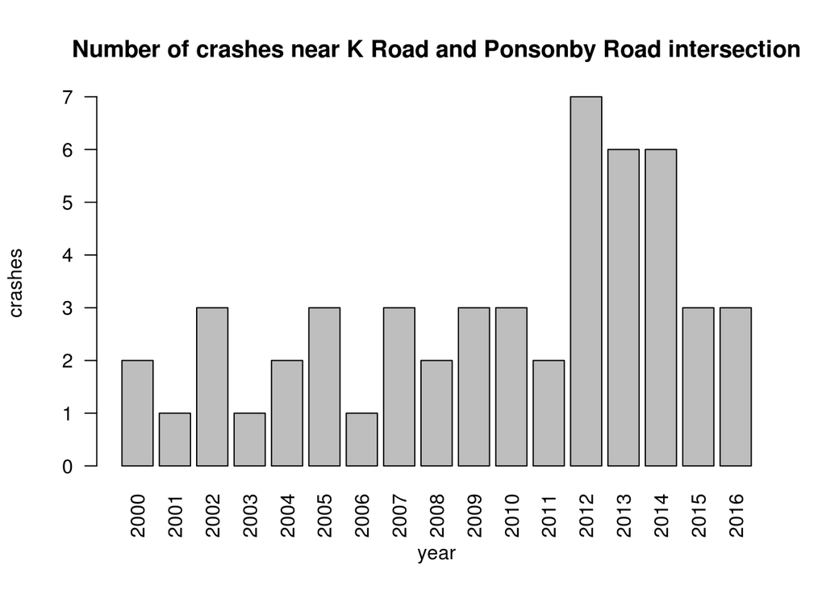

```r
crashesByYear = table(intersectionData$crash_year)
barplot(
    height = crashesByYear,
    las = 2,
    main = "Number of crashes near K Road and Ponsonby Road intersection",
    xlab = "year",
    ylab = "crashes")
```

```r
nFatalInjuries = sum(intersectionData$fatal_count)
nSeriousInjuries = sum(intersectionData$seriousinj_count)
nMinorInjuries = sum(intersectionData$minorinj_count)
```

There have been 0 fatal injuries, 9 serious injuries, and 54 minor injuries, in these 51 crashes.

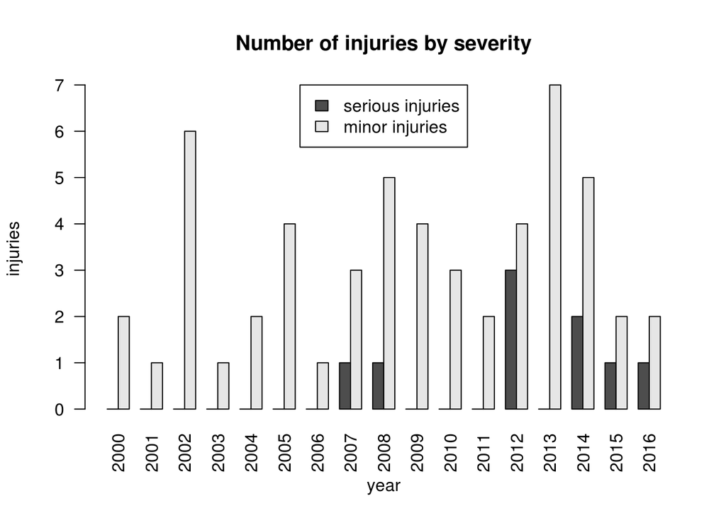

```r
seriousInjuriesByYear = aggregate(
    formula = seriousinj_count ~ crash_year,
    data = intersectionData,
    FUN = "sum")
minorInjuriesByYear = aggregate(
    formula = minorinj_count ~ crash_year,
    data = intersectionData,
    FUN = "sum")
injuriesByYear = merge(
    x = seriousInjuriesByYear,
    y = minorInjuriesByYear)

barplot(
    height = t(injuriesByYear[, 2:3]),
    args.legend = list(x = "top"),
    beside = TRUE,
    las = 2,
    legend.text = c("serious injuries", "minor injuries"),
    main = "Number of injuries by severity",
    names.arg = injuriesByYear[, 1],
    xlab = "year",
    ylab = "injuries")
```

```r
nSeriousCrashes =
    sum(intersectionData$seriousinj_count > 0)
nMinorCrashes =
    sum(intersectionData$minorinj_count > 0)
```

9 crashes resulted in serious injuries, and 43 crashes resulted in minor injuries.

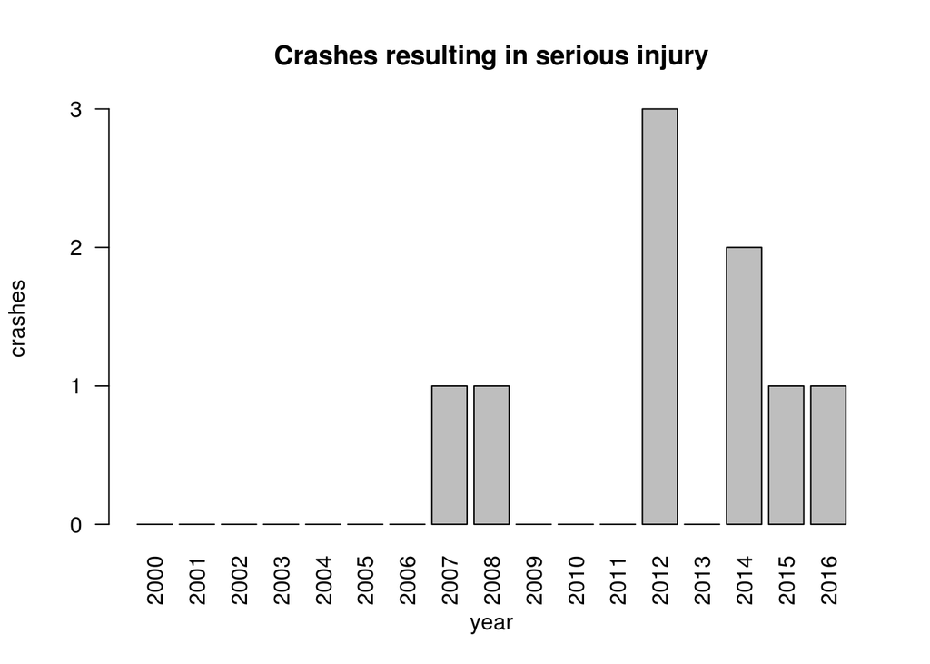

```r
crashesSeriousYear = aggregate(
    formula = seriousinj_count ~ crash_year,
    data = intersectionData[intersectionData$seriousinj_count > 0, ],
    FUN = "length")
crashesSeriousYear = merge(
    x = crashesSeriousYear,
    y = data.frame(crash_year = minYear:maxYear),
    all.y = TRUE)
crashesSeriousYear[is.na(crashesSeriousYear)] = 0

barplot(
    height = crashesSeriousYear[, 2],
    axes = FALSE,
    las = 2,
    main = "Crashes resulting in serious injury",
    names.arg = crashesSeriousYear[, 1],
    xlab = "year",
    ylab = "crashes")
axis(side = 2,
     at = min(crashesSeriousYear[, 2]):max(crashesSeriousYear[, 2]),
     las = 2)
```

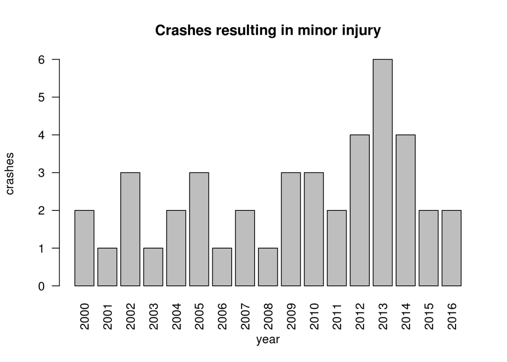

```r
crashesMinorYear = aggregate(
    formula = minorinj_count ~ crash_year,
    data = intersectionData[
        intersectionData$minorinj_count > 0
        & intersectionData$seriousinj_count == 0, ],
    FUN = "length")

barplot(
    height = crashesMinorYear[, 2],
    las = 2,
    main = "Crashes resulting in minor injury",
    names.arg = crashesMinorYear[, 1],
    xlab = "year",
    ylab = "crashes")
```

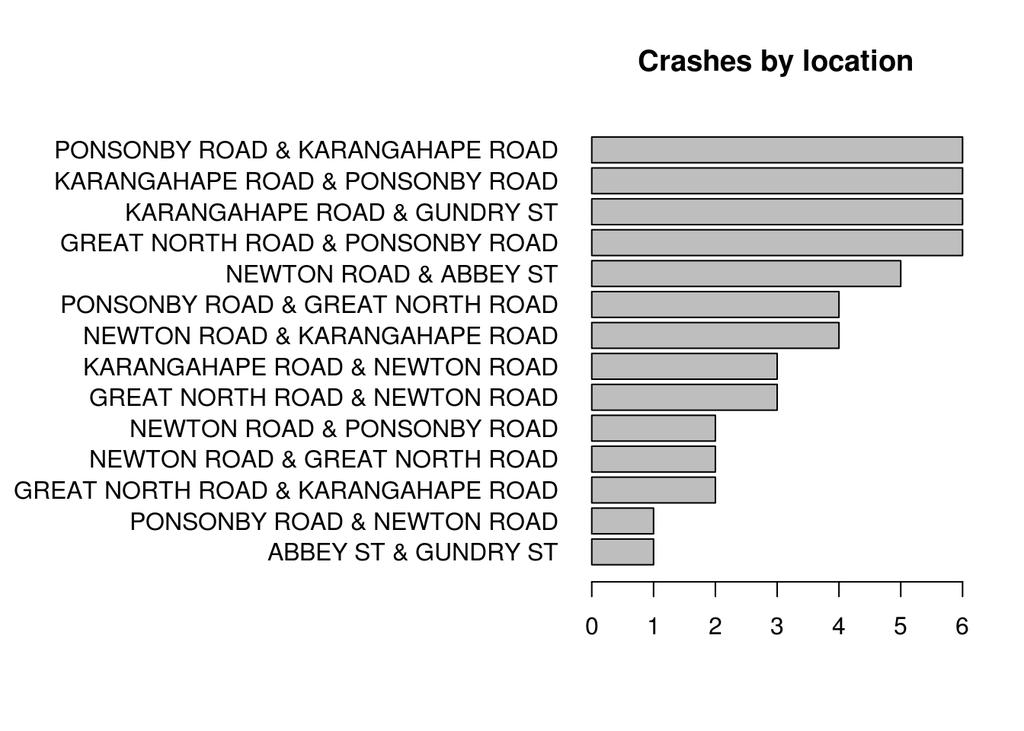

```r
crashLocation = paste(
    intersectionData$crash_locn1,
    intersectionData$crash_locn2,
    sep = " & ")
crashLocation = sort(table(crashLocation))

opar = par(mar = c(5.1, 20.1, 4.1, 2.1))
barplot(
    height = crashLocation,
    horiz = TRUE,
    las = 1,
    main = "Crashes by location")
```

```r
par(opar)
```